# Topic 2; Shrinkage: Lasso, Ridge Regression, Elastic Net

Jonas Mikkelsen

28/5/2021

# Shrinkage

When increasing the number of explanatory variables in the case of a small number of observations, it can have a severe effect on the estimates due to high correlation.

The idea behind shrinkage is that we fit a model involving all predictors, but then shrink the coefficients towards zero in order to reduce the variance.

As an example, consider

$$\begin{align*}
\begin{bmatrix}
x_1 \\
x_2 \\
\end{bmatrix}
\sim \mathcal{N}\left(\begin{bmatrix}
0\\
0\\
\end{bmatrix},
\begin{bmatrix}
1 & \sigma\\
\sigma & 1\\
\end{bmatrix}
\right),\quad y = x_1-x_2+u,\quad u\sim\mathcal{N}(0,1)
\end{align*}$$

Now estimate $y=\beta_1x_1+\beta_2x_2+\varepsilon$. Then

$$\begin{align*}
Var
\begin{bmatrix}
\hat{\beta}_1 \\
\hat{\beta}_2\\
\end{bmatrix}
= \sigma_\varepsilon^2
\begin{bmatrix}
\frac{1}{1-\sigma^2}\\
\frac{1}{1-\sigma^2}\\
\end{bmatrix}
\end{align*}$$

To show this, recall that $\hat{\beta}=\begin{bmatrix} \hat{\beta}_1\\ \hat{\beta}_2\\ \end{bmatrix} = (X^TX)^{-1}X^Ty$ and $Var(\hat{\beta}) = \sigma_\varepsilon^2(X^TX)^{-1}$. So to compute the variance, we need to compute $(X^TX)^{-1}$. Thus

$$\begin{align*}
X^TX &= \begin{bmatrix} x_1 & x_2 \end{bmatrix}^T \begin{bmatrix} x_1 & x_2\end{bmatrix}\\
& = \begin{bmatrix} x_1^T \\ x_2^T \\ \end{bmatrix} \begin{bmatrix} x_1 & x_2 \end{bmatrix}\\
& = \begin{bmatrix} x_1^Tx_1 & x_1^Tx_2 \\ x_2^Tx_1 & x_2^Tx_2\\ \end{bmatrix}\\
\end{align*}$$

which entails by the use of the determinant formula

$$\begin{align*}
(X^TX)^{-1} = \begin{bmatrix} x_2^Tx_2 & -x_1^Tx_2 \\ -x_2^Tx_1 & x_1^Tx_1\\ \end{bmatrix}
\frac{1}{(x_1^Tx_1)(x_2^Tx_2)-(x_1^Tx_2)^2}
\end{align*}$$

where we used the fact that $(x_1^Tx_2)^T=x_2^Tx_1$ and they are scalars. Hence

$$\begin{align*}
Var(\hat{\beta}_1) &= \frac{x_2^Tx_2}{(x_1^Tx_1)(x_2^Tx_2)-(x_1^Tx_2)^2}\\
&=\frac{1}{x_1^Tx_1-\frac{(x_1^Tx_2)^2}{x_2^Tx_2}}\\
&=\frac{1}{1-\frac{(x_1^Tx_2)^2}{x_1^Tx_1x_2^Tx_2}}
\end{align*}$$

Now noting that $(x_1^Tx_2)$ approaches the covariation between $x_1$ and $x_2$, and $x_2^Tx_2$ approaches the variance of $x_2$, while $x_1^Tx_1$ approaches the variance of $x_1$, we get that the fraction approaches the correlation squared. Hence

$$\begin{align*}
Var(\hat{\beta}_1) = \frac{1}{1-\sigma^2}.
\end{align*}$$

Similar results can be obtained for the variance of $\hat{\beta}_2$. This shows that the variance of our estimates increases if the correlation between the columns of our data is high.

Returning to the original problem, shrinkage is done by imposing a penalty by the size of the estimated parameters.

## Ridge regression

Rigde regression imposes a penalty to the coefficients by their $\ell_2$ norm, i.e. rigde regression minimizes

$$\begin{align*}
\sum_{i=1}^n(y_i-\beta_0-\sum_{j=1}^p\beta_jx_{i,j})^2+\lambda\sum_{j=1}^p\beta_j^2
= RSS + \lambda\sum_{j=1}^p\beta_j^2
\end{align*}$$

$\lambda$ is known as a tuning parameter that needs to be determined seperately. Notice that $\beta_0$ is not being penalized. The extra term is called the shrinkage penalty. If $\lambda = 0$, then no penalty exists and we have ordinary linear regression. If $\lambda\rightarrow \infty$, the coefficients are forced to $0$, and the estimate collapses to the mean value.

It is possible to solve ridge analytically. In matrix form, we thus want to minimize

$$\begin{align*}
RSS(\lambda) = (Y-X\beta)^T(Y-X\beta)+\lambda\beta^T\beta
\end{align*}$$

Let the lagrange function be defined as $\mathcal{L} = RSS(\lambda)$. Then we have

$$\begin{align*}
\mathcal{L}(\beta) = Y^TY-Y^TX\beta-\beta^TX^TY+\beta^TX^TX\beta+\lambda\beta^T\beta
\end{align*}$$

Taking the derivative w.r.t. $\beta$ and equating to $0$ yields

$$\begin{align*}
\frac{\partial L}{\partial \beta} = -2 Y^TX+2\beta^TX^TX+2\lambda\beta^T &= 0\\
\Updownarrow\\
\beta^TX^TX+\lambda\beta^T &= Y^TX\\
\Updownarrow\\
\beta^T &= Y^TX(X^TX+\lambda I)^{-1}\\
\Updownarrow\\
\hat{\beta}^R &= (X^TX+\lambda I)^{-1}X^TY
\end{align*}$$

This is OLS regression if we remove the $\lambda I$ term. Ridge also helps with non-invertability of $X^TX$. If the columns are linear dependent or close to, this matrix is not invertable, but since we add the scaled identity to the term, it is always invertable, because we just add $\lambda$ to the diagonal.

### Considerations

In linear regression, different scales in variables are absorbed into the estimated parameters. This is not the case for shrinkage methods. Hence it is necessary to standardize the explanatory variables before applying ridge regression.

The tuning parameter, $\lambda$, is usually determined by cross-validation.

## Lasso

Lasso is similar to Ridge, but instead of imposing an $\ell_2$ penalty, it imposes an $\ell_1$ penalty. Hence, lasso minimizes

$$\begin{align*}
\sum_{i=1}^n(y_i-\beta_0-\sum_{j=1}^p\beta_jx_{i,j})^2+\lambda\sum_{j=1}^p|\beta_j|
= RSS + \lambda\sum_{j=1}^p|\beta_j|
\end{align*}$$

$\lambda$ is once again a tuning parameter, determined separately. If $\lambda = 0$, we have the ordinary linear regression, if $\lambda\rightarrow \infty$, the coefficients are forced to $0$ and we get the mean.

The main difference here is that lasso can actually make coefficients exactly $0$, meaning that it can be used to remove columns from a data set. On the other hand, ridge was nice because it have closed form solutions for the estimates. This is not the case for lasso, because the function $x\mapsto |x|$ is not differentiable at $0$. As a result, we must use subdifferentials.

For simplification, we solve for one parameter at a time, holding the rest constant. Then move on to the second parameter, etc. Called cordinate descent, similar to a greedy algorithm.

The first step is to solve for the intercept, which implies that we demean the data. If we think about RSS as just a function of $\beta_0$, then we get that

$$\begin{align*}
RSS(\beta_0) = \sum_{i=1}^N(y_i-\beta_0-\sum_{j=1}^px_{i,j}\beta_j)^2.
\end{align*}$$

Because $\beta_0$ does not appear in the penalty term. Then

$$\begin{align*}
\frac{\partial RSS}{\partial \beta_0} = 2\sum_{i=1}^N(y_i-\beta_0-\sum_{j=1}^px_{i,j}\beta_j) = 0
\end{align*}$$

which implies $\hat{\beta_0} = \frac{1}{N}\left(\sum_{i=1}^Ny_i-\sum_{j=1}^px_{i,j}\beta_j\right) = \bar{y}-\sum_{j=1}^p\bar{x}_j\beta_j$. Then after demeaning, coordinate descent are looking to minimize

$$\begin{align*}
\frac{1}{2N}\sum_{i=1}^N\left(y_i-\sum_{j=1}^p x_{i,j}\beta_j\right)^2+\lambda\sum_{j=1}^p
|\beta_j|
\end{align*}$$

Assume that we are looking for the $k'th$ parameter, $1\leq k\leq p$. If we let $\mathcal{L} = \frac{1}{2N}\sum_{i=1}^N\left(y_i-\sum_{j=1}^p x_j\beta_j\right)^2+\lambda\sum_{j=1}^p |\beta_j|$, then we get that

$$\begin{align*}
\frac{\partial L}{\partial\beta_k} &= \frac{1}{N}\sum_{i=1}^N (y_i-\sum_{j=1}^p
x_{i,j}\beta_j)(-x_{i,k}) + \lambda \frac{\partial}{\partial\beta_k}|\beta_k|\\
&= -\frac{1}{N}\sum_{i=1}^N x_{i,k}(y_i-\sum_{j\neq k}\beta_jx_{i,j}-\beta_kx_{i,k})
+ \lambda \frac{\partial}{\partial\beta_k}|\beta_k|\\
&= -\frac{1}{N}\sum_{i=1}^N x_{i,k}(y_i-\sum_{j\neq k}\beta_jx_{i,j})
+ \frac{1}{N}\beta_k\sum_{i=1}^N x_{i,k}^2 + \lambda \frac{\partial}{\partial\beta_k}|\beta_k|\\
&= -\frac{1}{N}\sum_{i=1}^N x_{i,k}r_{i,k}+ \frac{1}{N}\beta_k\sum_{i=1}^N x_{i,k}^2 +
\lambda \frac{\partial}{\partial\beta_k}|\beta_k|\\
&= -\frac{1}{N} x_k^T r_k +\frac{1}{N}\beta_k x_{k}^T x_k + \lambda \frac{\partial}{\partial\beta_k}|\beta_k|\\
\end{align*}$$

What is left is the subdifferential. Hence

$$\begin{align*}
\lambda \frac{\partial}{\partial\beta_k}|\beta_k| = \begin{cases}
-\lambda, & \text{if } \beta_k < 0\\
[-\lambda,\lambda], & \text{if } \beta_k = 0\\
\lambda, & \text{if } \beta_k > 0
\end{cases}
\end{align*}$$

this yields that

$$\begin{align*}
\frac{\partial L}{\partial\beta_k} = \begin{cases}
-\frac{1}{N} x_k^T r_k +\frac{1}{N}\beta_k x_{k}^T x_k - \lambda & \text{if } \beta_k < 0\\
[-\frac{1}{N} x_k^T r_k-\lambda, -\frac{1}{N} x_k^T r_k+\lambda] & \text{if } \beta_k = 0 \\
-\frac{1}{N} x_k^T r_k +\frac{1}{N}\beta_k x_{k}^T x_k + \lambda & \text{if } \beta_k > 0
\end{cases}
\end{align*}$$

Each of these cases must be equated to $0$. For the first one we get that

$$\begin{align*}
\beta_k = (\frac{1}{N}x_k^Tr_k+\lambda)(\frac{1}{N}x_k ^T x_k)^{-1}
\end{align*}$$

this happens if $\beta_k < 0$, which is when $\frac{1}{N}x_k^T r_k < -\lambda$. Similar results can be done for the other cases, which yields

$$\begin{align*}
\hat{\beta_k} = \begin{cases}
(\frac{1}{N}x_k^Tr_k+\lambda)(\frac{1}{N}x_k ^T x_k)^{-1} & \text{if }
\frac{1}{N}x_k^T r_k < -\lambda\\
0 & \text{if } -\lambda\leq \frac{1}{N}x_k^Tr_k\leq \lambda\\
(\frac{1}{N}x_k^Tr_k-\lambda)(\frac{1}{N}x_k ^T x_k)^{-1} & \text{if }
\frac{1}{N}x_k^T r_k > \lambda\\
\end{cases}
\end{align*}$$

This can also be expressed using the soft-threshold operator defined as $S_\lambda(z) = sign(z)(|z|-\lambda)^+$. Consequently,

$$\begin{align*}
\hat{\beta}_k = (\frac{1}{N}x_k^T x_k)^{-1} S_\lambda(\frac{1}{N}x_k^T r_k)
\end{align*}$$

### Considerations

Lasso is also affected by scaling of explanatory variables. Standardize should be considered. Lasso makes variable selection by putting some variables equal to zero. Helps with model interpretability.

## Elastic Net

A combination of Ridge and Lasso. The idea is the same as previosly, but Elastic net combines the two methods. Hence, it looks to minimize the function

$$\begin{align*}
\sum_{i=1}^N(y_i-\beta_0-\sum_{j=1}^p\beta_jx_{i,j})^2+\lambda\sum_{j=1}^p
(\alpha |\beta_j|+(1-\alpha)\beta_j^2)
\end{align*}$$

$\lambda,\alpha$ are tuning parameters determined seperately. Shrinkage pentalty is a combination (weighted average) of the penalties for ridge and lasso. Elastic net selects variables just like lasso, and also shrinks the coefficients of correlated predictors like in the rigde. Assume once again that we have demeaned the data. Hence we instead look at

$$\begin{align*}
\mathcal{L} = \frac{1}{2N}\sum_{i=1}^N(y_i-\sum_{j=1}^p\beta_jx_{i,j})^2+\lambda\sum_{j=1}^p
(\alpha |\beta_j|+\frac{1}{2}(1-\alpha)\beta_j^2)
\end{align*}$$

We now try to find the derivative of the $k'th$ $\beta$. The procedure is the same as in lasso. Thus

$$\begin{align*}
\frac{\partial \mathcal{L}}{\partial\beta_k} &= -\frac{1}{N}\sum_{i=1}^Nx_{i,k}(y_i-
\sum_{j=1}^p\beta_jx_{i,j}) + \lambda\alpha \frac{\partial}{\partial\beta_k}|\beta_k|
+\lambda(1-\alpha)\beta_k\\
&= -\frac{1}{N}x_k^Tr_k+\frac{1}{N}\beta_kx_k^Tx_k+\lambda\alpha \frac{\partial}{\partial\beta_k}|\beta_k|
+\lambda(1-\alpha)\beta_k\\
\end{align*}$$

Hence when equating to zero and solving for $\beta_k$ yields

$$\begin{align*}
\hat{\beta}_k = \begin{cases}
(\frac{1}{N}x_k^Tr_k+\lambda\alpha)\frac{1}{\lambda(1-\alpha)}(\frac{1}{N}
x_k^T x_k)^{-1} & \text{if } \frac{1}{N}x_k^Tr_k < -\lambda\alpha\\
\hat{\beta}_k = 0 & \text{if } -\lambda\alpha\leq\frac{1}{N}x_k^Tr_k\leq\alpha\lambda\\
\hat{\beta}_k = (\frac{1}{N}x_k^Tr_k-\lambda\alpha)\frac{1}{\lambda(1-\alpha)}(\frac{1}{N}
x_k^T x_k)^{-1} & \text{if } \frac{1}{N}x_k^Tr_k > \lambda\alpha\\
\end{cases}
\end{align*}$$

Or by use of the soft-threshold operator,

$$\begin{align*}
\hat{\beta_k} = (\frac{1}{N}x_k^Tx_k)\frac{1}{\lambda(1-\alpha)}S_{\lambda,\alpha}
(\frac{1}{N}x_k^Tr_k)
\end{align*}$$

### Extensions

Shrinkage can also be applied to classification problems (e.g. Neural Networks) by properly adjusting the optimization problem. This can be done by restricting some of the parameters. For example, in logistic regression, lasso maximizes

$$\begin{align*}
\sum_{i=1}^N(y_iX_i\beta-\log(1+e^{X_i\beta}))-\lambda\sum_{j=1}^p|\beta_j|
\end{align*}$$

## Practical implementation on BikeSharing data set

```r
suppressMessages(library(tidyverse))
suppressMessages(library(glmnet))
suppressMessages(library(ggplot2))
suppressMessages(data <- read_csv("day.csv")) # Getting the data
dat <- data %>% select(cnt, windspeed, atemp, hum) #Selecting some variables to work with
head(data)
```

```
## # A tibble: 6 x 16
##   instant dteday     season    yr  mnth holiday weekday workingday weathersit
##     <dbl> <date>      <dbl> <dbl> <dbl>   <dbl>   <dbl>      <dbl>      <dbl>
## 1       1 2011-01-01      1     0     1       0       6          0          2
## 2       2 2011-01-02      1     0     1       0       0          0          2
## 3       3 2011-01-03      1     0     1       0       1          1          1
## 4       4 2011-01-04      1     0     1       0       2          1          1
## 5       5 2011-01-05      1     0     1       0       3          1          1
## 6       6 2011-01-06      1     0     1       0       4          1          1
## # ... with 7 more variables: temp <dbl>, atemp <dbl>, hum <dbl>,
## #   windspeed <dbl>, casual <dbl>, registered <dbl>, cnt <dbl>
```

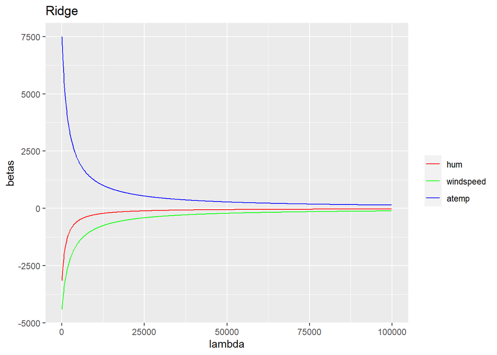

```r
mod <- glmnet(y = dat$cnt, x = (dat %>% select(-cnt)), data = dat, alpha = 0,
              family = "gaussian", lambda = seq(1,100000,100)) #Alpha = 0 is ridge

coefficients <- mod$beta %>% as.matrix() %>% t() %>% data.frame
rownames(coefficients) <- NULL

Plot_Data <- coefficients %>% mutate(mod$lambda) %>% rename("lambda" = "mod$lambda")

ggplot(data = Plot_Data, aes(x = lambda)) +
  geom_line(aes(y = hum, color = "hum")) +
  geom_line(aes(y = windspeed, color = "windspeed")) +
  geom_line(aes(y = atemp, color = "atemp")) +
  scale_color_manual("", breaks = c("hum", "windspeed", "atemp"),
                     values = c("red", "green", "blue")) +
  ylab("betas") +
  ggtitle("Ridge")
```

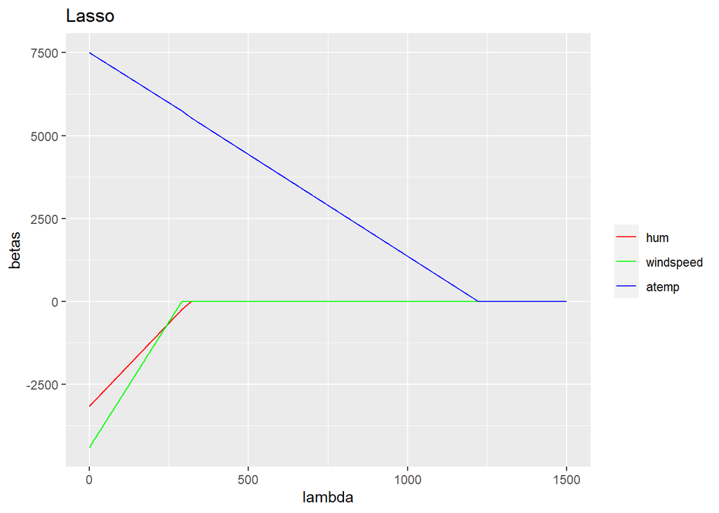

```r
#Lets try lasso

mod <- glmnet(y = dat$cnt, x = (dat %>% select(-cnt)), data = dat, alpha = 1,
              family = "gaussian", lambda = seq(1,1500,1))

coefficients <- mod$beta %>% as.matrix() %>% t() %>% data.frame
rownames(coefficients) <- NULL

Plot_Data <- coefficients %>% mutate(mod$lambda) %>% rename("lambda" = "mod$lambda")

ggplot(data = Plot_Data, aes(x = lambda)) +
  geom_line(aes(y = hum, color = "hum")) +
  geom_line(aes(y = windspeed, color = "windspeed")) +
  geom_line(aes(y = atemp, color = "atemp")) +
  scale_color_manual("", breaks = c("hum", "windspeed", "atemp"),
                     values = c("red", "green", "blue")) +
  ylab("betas") +
  ggtitle("Lasso")
```

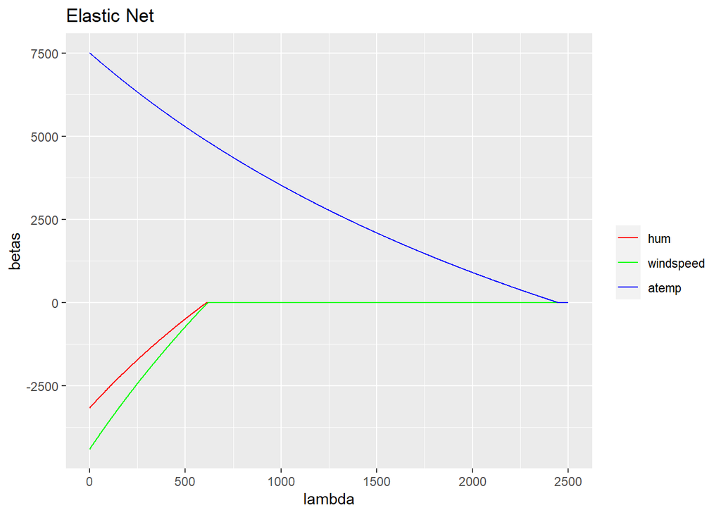

```r
#Last, elastic net with alpha = 0.5

mod <- glmnet(y = dat$cnt, x = (dat %>% select(-cnt)), data = dat, alpha = 0.5,
              family = "gaussian", lambda = seq(1,2500,1))

coefficients <- mod$beta %>% as.matrix() %>% t() %>% data.frame
rownames(coefficients) <- NULL

Plot_Data <- coefficients %>% mutate(mod$lambda) %>% rename("lambda" = "mod$lambda")

ggplot(data = Plot_Data, aes(x = lambda)) +
  geom_line(aes(y = hum, color = "hum")) +
  geom_line(aes(y = windspeed, color = "windspeed")) +
  geom_line(aes(y = atemp, color = "atemp")) +
  scale_color_manual("", breaks = c("hum", "windspeed", "atemp"),
                     values = c("red", "green", "blue")) +
  ylab("betas") +
  ggtitle("Elastic Net")
```